# Business Case Monte Carlo Solution

## Solution

**Build a deterministic model under the following assumptions:**

*Market Assumptions*

- Patients treated: 100,000, supposed to increase 1% per year
- Patients expected Market share: 20%, expected to increase 1% per year in the first 5 years, then stable
- Days of treatment per year = 365; Daily dosage: 2 pills; Pills x pack = 60
- Ex Factory Price x pack = 30, increasing with an inflation rate of 2%
- Weighted average commercial discount = 7%

*Costs Assumptions*

- COGS x pack (including delivery costs) = 9, increasing with an inflation rate of 2%
- Royalties = 20% of Gross Sales
- Yearly Promotional Expenses & Reps = 2,000,000
- Up-front payment = 3,500,000(immediate)

*Working Capital Assumptions*

- Accounts receivables, DSO (days) = 60
- Inventory, DSI (days) = 90
- Accounts payables, DPO (days) = 75
- Tax rate = 30%
- Weighted Average Cost of Capital = 8.0%

**Tip**

First of all we need to import the libraries that we will use and two additional functions to compute: (i) Net Present value (takes the cashflows and the discount rate as inputs); (ii) Internal Rate of Return (takes the cashflows as input). Everything is stored in the R script uploaded on the moodle `functions_packages.R`

```r
rm(list=ls())

source("C:\\Users\\aless\\OneDrive\\Desktop\\Vienna\\functions_packages.R")
```

We need to store all available information in variables within the R script.

```r
## Available informations
time.period = 10

## Patients to treat
patients.t0 = 100000
patients.grate = rep(0.01, time.period) ## constant for all 10 years

## Market share
mkt.share.t0 = 0.2
mkt.share.grate = c(rep(0.01, time.period/2), rep(0, time.period/2)) ## 1% first 5 years and after stable

## Treatment info
treat.days.year = 365
dosage.daily = 2
pack.dosage = 60

## Pack cost info
pack.cost.t0 = 30
pack.cost.grate = rep(0.02, time.period) ## constant for all 10 years
pack.discount = 0.07

## Costs info
var.cost.t0 = 9
var.cost.grate = rep(0.02, time.period) ## constant for 10 years
royalties.rate = 0.2 ## 20% of gross sales
fixed.cost = 2000000

## Investments info
investment.t0 = 3500000 ## depreciation in 10 years
## investment for next 10 years
investment = c(investment.t0, ## investment t0
               rep(0, 10) ## investment t1-t10
               )

## Working capital info
tax.rate = 0.3
dso = 60
dsi = 90
dop = 75
wacc = 0.08
```

Next, we must develop a model to calculate the expected cash flows based on the given assumptions.

To do this, we first quantify the target market by calculating the number of patients eligible for treatment and the market share over the entire period considered.

NB. The number of patients in year t (as well as the market share) is determined using the provided growth rate:

$x_{t}=x_{t_{0}}*(1+r)^{t}$

We can now calculate the number of patients treated as the product of the number of patients eligible for treatment and the market share:

$X_{t}=patients_{t}*mkt\_share_{t}$

Next, we determine the number of packs sold annually, considering the daily pill dosage, the number of pills per pack, and the number of treatment days. The total number of packs sold is given by:

$pack\_sold_{t}=\frac{X_{t}*treat\_days*daily\_dosage}{pack\_dosage}$

Finally, we can compute the gross revenue for the next 10 years by multiplying the selling price per pack by the number of packs sold:

$gross\_revenues_{t}=pack\_sold_{t}*pack\_price_{t}$

Net revenue is then obtained by applying the 7% discount:

$net\_revenues_{t}=gross\_revenues_{t}*(1-0.07)$

NB. The selling price at time t is calculated similarly to the number of patients and market share, using the assumed growth rate

```r
## patients for next 10 years
patients = c(patients.t0, patients.t0*(1+patients.grate)^c(1:(time.period)))

## mkt share for next 10 years
mkt.share = c(mkt.share.t0,mkt.share.t0*(1+mkt.share.grate)^c(1:(time.period)))

## pack cost for next 10 years
pack.cost = c(pack.cost.t0, pack.cost.t0*(1+pack.cost.grate)^c(1:(time.period)))


## Patients treated
patients.treated = patients*mkt.share

## Packs sold
pack.sold = patients.treated*treat.days.year*dosage.daily/pack.dosage

gross.revenues = pack.sold*pack.cost ## gross revenues
net.revenues = gross.revenues*(1-pack.discount) ## net revenues
```

Now, let’s consider the costs. We calculate variable costs as the product of the number of packs sold and the variable cost per pack. Additionally, we include royalties, which are calculated as 20% of the total gross revenue

We now have all the elements to compute the gross profit, which is given by the difference between gross revenue and total variable costs:

$gross\_profits_{t}=gross\_revenues_{t}-var\_costs_{t}-royalties_{t}$

The EBITDA is then obtained by subtracting fixed costs of €2,000,000 from the gross profit

To calculate EBIT, we need to consider the depreciation plan, which we assume to be constant over the 10-year period:

$deprecetation_{t}=\frac{total\_investment}{T}$

The EBIT is then computed as:

$EBIT_{t}=EBITDA_{t}-deprecetation_{t}$

While the Net profit as:

```r
## variable costs for next 10 years
var.cost = c(var.cost.t0, var.cost.t0*(1+var.cost.grate)^c(1:(time.period)))

var.cost = var.cost*pack.sold ## amount of variable costs

royalties = gross.revenues*royalties.rate ## amount of royalties

tot.var.cost = var.cost+royalties ## total variable costs

gross.profit = gross.revenues-tot.var.cost ## gross profit

ebitda = gross.profit-fixed.cost ## ebitda

## deprecetation plan
depre.plan = rep(sum(investment)/time.period, time.period)

ebit = ebitda-depre.plan ## ebit

net.profit = ebit*(1-tax.rate) ## net profit
```

We can now compute the expected cashflows taking into the self-financing, the cash generated before considering changes in working capital, and the following working capital assumptions:

- DSO (Days Sales Outstanding) = 60: The average number of days to collect receivables
- DSI (Days Sales of Inventory) = 90: The average number of days inventory is held before being sold
- DPO (Days Payable Outstanding) = 75: The average number of days to pay suppliers

We can thus roughly (i) estimate the amount the company is expected to collect from sales over a year; (ii) estimate the amount of inventory held by the company over a year; (iii) estimate the amount the company owes to suppliers

We can compute the working capital as the sum of expected revenues and inventory minus the accounts payable

Finally, we compute the operating cash flow as the self financing minus the change in working capital, where the latter is the year-on-year change of the working capital and the free cash flow

The free cash flow is calculated by subtracting the capital invested from the operating cash flow

```r
## self financing
self.financing = ebit+depre.plan-ebit*tax.rate

account.rec = net.revenues*dso/365 ## accounts receivable

inventory = var.cost*dsi/365 ## inventory

account.pay = tot.var.cost*dop/365 ## accounts payable

## working capital
working.capital = account.rec+inventory-account.pay

## delta working capital
delta.working.capital = working.capital-c(0, na.omit(lag(working.capital, 1)))

## operating cashflow
operating.cashflow = self.financing-delta.working.capital

## free cashflow
free.cashflow = operating.cashflow-c(investment.t0, rep(0, 10))
```

We can now compute the Net Present Value (assuming the weighted cost of capital of 8%) and the Internal rate of return

```r
NPV = npv(cf = free.cashflow, k = wacc)
IRR = irr(cf = free.cashflow)
```

```r
cat(paste0("Net present value: ", round(NPV, 2)))
```

```
Net present value: 8165259.73
```

```r
cat(paste0("Internal rate of return: ", round(IRR*100, 2), "%"))
```

```
Internal rate of return: 47.21%
```

**Due to the high level of uncertainty, the Corporate Marketing Director asks for a deeper analysis using the above information but considering a stochastic (Montecarlo Simulation) approach. Modify the model accordingly and prepare a report on the results**

Specifically, assume:

- that the patient growth rate can range between -0.1 and 0.1
- the market share growth rate follows a normal distribution with a mean of 0.01 and a standard deviation of 0.005
- the inflation rate follows a triangular distribution centered around 2.5%, with a minimum of 1% and a maximum of 4%
- the discount rate is uniformly distributed between 0.04 and 0.08

**Tip**

```r
compute_cf = function(p.grate, mkt.grate, var.cost.rate, pack.discount.inp){



## p.grate: patients growth rate
## mkt.grate: market share growth rate
## var.cost.rate: var cost growth rate
## pack.discount.inp: weighted average commercial discount

## Available informations
time.period = 10

## Patients to treat
patients.t0 = 100000
## Patient growth rate (INPUT)
patients.grate = rep(p.grate, time.period) ## constant for all 10 years

## Market share
mkt.share.t0 = 0.2
## Market share growth rate (INPUT)
mkt.share.grate = c(rep(mkt.grate, time.period))

## Treatment info
treat.days.year = 365
dosage.daily = 2
pack.dosage = 60

## Pack cost info
pack.cost.t0 = 30
## Pack cost growth rate
pack.cost.grate = rep(0.02, time.period) ## constant for all 10 years
## Pack discount (INPUT)
pack.discount = pack.discount.inp

## Costs info
var.cost.t0 = 9
## Variable cost growth rate (INPUT)
var.cost.grate = rep(var.cost.rate, time.period) ## constant for 10 years
royalties.rate = 0.2 ## 20% of gross sales
fixed.cost = 2000000

## Investments info
investment.t0 = 3500000 ## depreciation in 10 years
## investment for next 10 years
investment = c(investment.t0, ## investment t0
               rep(0, 10))

tax.rate = 0.3
dso = 60
dsi = 90
dop = 75
wacc = 0.08


## patients for next 10 years
patients = c(patients.t0, patients.t0*(1+patients.grate)^c(1:(time.period)))
mkt.share = c(mkt.share.t0,mkt.share.t0*(1+mkt.share.grate)^c(1:(time.period)))
pack.cost = c(pack.cost.t0, pack.cost.t0*(1+pack.cost.grate)^c(1:(time.period)))
patients.treated = patients*mkt.share
pack.sold = patients.treated*treat.days.year*dosage.daily/pack.dosage
gross.revenues = pack.sold*pack.cost
net.revenues = gross.revenues*(1-pack.discount)
var.cost = c(var.cost.t0, var.cost.t0*(1+var.cost.grate)^c(1:(time.period)))
var.cost = var.cost*pack.sold
royalties = gross.revenues*royalties.rate
tot.var.cost = var.cost+royalties
gross.profit = gross.revenues-tot.var.cost
ebitda = gross.profit-fixed.cost
depre.plan = rep(sum(investment)/time.period, time.period)
ebit = ebitda-depre.plan
net.profit = ebit*(1-tax.rate)
self.financing = ebit+depre.plan-ebit*tax.rate
account.rec = net.revenues*dso/365
inventory = var.cost*dsi/365
account.pay = tot.var.cost*dop/365
working.capital = account.rec+inventory-account.pay
delta.working.capital = working.capital-c(0, na.omit(lag(working.capital, 1)))
operating.cashflow = self.financing-delta.working.capital


free.cashflow = operating.cashflow-c(investment.t0, rep(0, 10))

return(free.cashflow)

}
```

To run a Monte Carlo simulation, we can use the function created earlier, simulating the inputs according to the requirements in the text. Note: the triangular function is not included in base R, so you need to install and import the EnvStats package (using the `rtri()` function). We can create the simulation either by vectorizing (the more efficient method) or using a for loop (which is simpler to implement in most cases)

```r
## set seed
set.seed(101)

## for loop
N = 1e3 ## 1000 simulations

## preparing vector where to store values
irr.vec = c()
npv.vec = c()

for(i in 1:N){

## patients growth rate: uniform
p.grate = runif(1, min = -0.1, max = 0.1)

## market share growth rate: normal
mkt.grate = rnorm(1, mean = 0.01, sd = 0.005)

## inflation rate: triangular
inflation.rate = rtri(1, min = 0.01, max = 0.04, mode = 0.025)

## discount rate: uniform
discount.rate = runif(1, min = 0.04, max = 0.08)

sim.res = compute_cf(p.grate = p.grate, mkt.grate = mkt.grate,
                     var.cost.rate = inflation.rate,
                     pack.discount.inp = discount.rate)

NPV.sim = npv(sim.res, k = wacc)
IRR.sim = irr(sim.res)

npv.vec = c(npv.vec, NPV.sim)
irr.vec = c(irr.vec, IRR.sim)

}
```

[figure not shown]

```r
## set seed
set.seed(101)

## Vectorizing

## patients growth rate: uniform
p.grate = runif(N, min = -0.1, max = 0.1)

## market share growth rate: normal
mkt.grate = rnorm(N, mean = 0.01, sd = 0.005)

## inflation rate: triangular
inflation.rate = rtri(N, min = 0.01, max = 0.04, mode = 0.025)

## discount rate: uniform
discount.rate = runif(N, min = 0.04, max = 0.08)

sim.res = mapply(compute_cf, p.grate, mkt.grate,
                 inflation.rate,discount.rate)

NPV.sim = apply(sim.res, 2, npv, k = wacc)
IRR.sim = apply(sim.res, 2, irr)
```

**Tip**

First, we can qualitatively assess which distribution best fits the given data. At first glance, the normal distribution appears to be a good fit. To statistically validate this choice, the Kolmogorov-Smirnov test could be used, though it is beyond the scope of this course. We can estimate then the mean and standard deviation from the data and adapt the function to accept as input also the patients at time t0 and run again the simulations having treating this parameter as stochastic

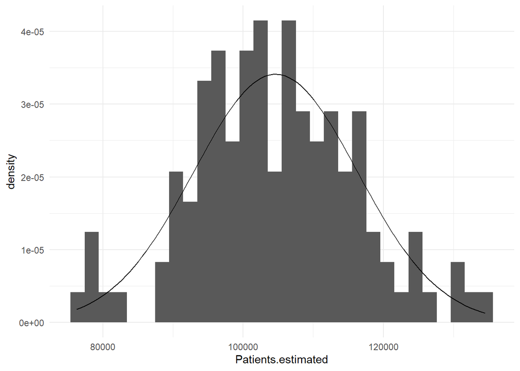

```r
dt.patient = read.xlsx("C:\\Users\\aless\\OneDrive\\Desktop\\Vienna\\Montecarlo\\Final\\Afternoon\\PullPill_Input.xlsx", sheet = "Patients t0")

ggplot(dt.patient, aes(x = Patients.estimated)) +
  geom_histogram(aes(y=..density..))+
  stat_function(fun = dnorm, args = list(mean = mean(dt.patient$Patients.estimated), sd = sd(dt.patient$Patients.estimated))) +
  theme_minimal()
```

```r
mu.patient = mean(dt.patient$Patients.estimated)
sd.patient = sd(dt.patient$Patients.estimated)
```

```r
compute_cf.udpate = function(p.grate, mkt.grate, var.cost.rate, pack.discount.inp, patients.t0){



## p.grate: patients growth rate
## mkt.grate: market share growth rate
## var.cost.rate: var cost growth rate
## pack.discount.inp: weighted average commercial discount

## Available informations
time.period = 10

## Patients to treat (INPUT)
## Patient growth rate (INPUT)
patients.grate = rep(p.grate, time.period) ## constant for all 10 years

## Market share
mkt.share.t0 = 0.2
## Market share growth rate (INPUT)
mkt.share.grate = c(rep(mkt.grate, time.period))

## Treatment info
treat.days.year = 365
dosage.daily = 2
pack.dosage = 60

## Pack cost info
pack.cost.t0 = 30
## Pack cost growth rate
pack.cost.grate = rep(0.02, time.period) ## constant for all 10 years
## Pack discount (INPUT)
pack.discount = pack.discount.inp

## Costs info
var.cost.t0 = 9
## Variable cost growth rate (INPUT)
var.cost.grate = rep(var.cost.rate, time.period) ## constant for 10 years
royalties.rate = 0.2 ## 20% of gross sales
fixed.cost = 2000000

## Investments info
investment.t0 = 3500000 ## depreciation in 10 years
## investment for next 10 years
investment = c(investment.t0, ## investment t0
               rep(0, 10))

tax.rate = 0.3
dso = 60
dsi = 90
dop = 75
wacc = 0.08


## patients for next 10 years
patients = c(patients.t0, patients.t0*(1+patients.grate)^c(1:(time.period)))
mkt.share = c(mkt.share.t0,mkt.share.t0*(1+mkt.share.grate)^c(1:(time.period)))
pack.cost = c(pack.cost.t0, pack.cost.t0*(1+pack.cost.grate)^c(1:(time.period)))
patients.treated = patients*mkt.share
pack.sold = patients.treated*treat.days.year*dosage.daily/pack.dosage
gross.revenues = pack.sold*pack.cost
net.revenues = gross.revenues*(1-pack.discount)
var.cost = c(var.cost.t0, var.cost.t0*(1+var.cost.grate)^c(1:(time.period)))
var.cost = var.cost*pack.sold
royalties = gross.revenues*royalties.rate
tot.var.cost = var.cost+royalties
gross.profit = gross.revenues-tot.var.cost
ebitda = gross.profit-fixed.cost
depre.plan = rep(sum(investment)/time.period, time.period)
ebit = ebitda-depre.plan
net.profit = ebit*(1-tax.rate)
self.financing = ebit+depre.plan-ebit*tax.rate
account.rec = net.revenues*dso/365
inventory = var.cost*dsi/365
account.pay = tot.var.cost*dop/365
working.capital = account.rec+inventory-account.pay
delta.working.capital = working.capital-c(0, na.omit(lag(working.capital, 1)))
operating.cashflow = self.financing-delta.working.capital


free.cashflow = operating.cashflow-c(investment.t0, rep(0, 10))

return(free.cashflow)

}


## for loop
N = 1e3 ## 1000 simulations

## preparing vector where to store values
irr.vec = c()
npv.vec = c()

for(i in 1:N){

## patients growth rate: uniform
p.grate = runif(1, min = -0.1, max = 0.1)

## market share growth rate: normal
mkt.grate = rnorm(1, mean = 0.01, sd = 0.005)

## inflation rate: triangular
inflation.rate = rtri(1, min = 0.01, max = 0.04, mode = 0.025)

## discount rate: uniform
discount.rate = runif(1, min = 0.04, max = 0.08)

## patient t0
patients.t0 = rnorm(1, mean = mu.patient, sd = sd.patient)

sim.res = compute_cf.udpate(p.grate = p.grate, mkt.grate = mkt.grate,
                     var.cost.rate = inflation.rate,
                     pack.discount.inp = discount.rate,
                     patients.t0 = patients.t0)

NPV.sim = npv(sim.res, k = wacc)
IRR.sim = irr(sim.res)

npv.vec = c(npv.vec, NPV.sim)
irr.vec = c(irr.vec, IRR.sim)

}
```

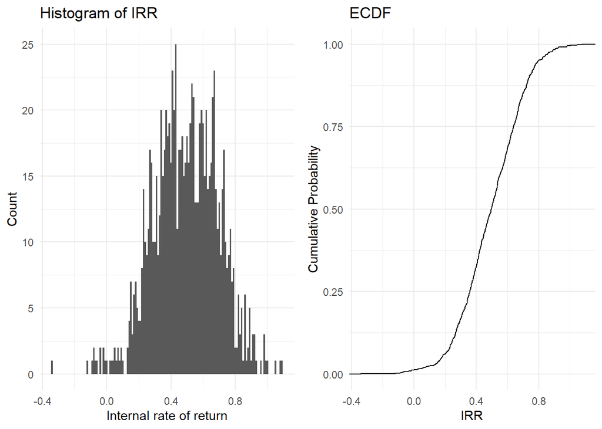

```r
p1 = irr.vec %>% as.data.frame() %>%
ggplot(aes(x=irr.vec)) +
  geom_histogram(binwidth = 0.01)+
  labs(x = "Internal rate of return",
       y = "Count",
       title = "Histogram of IRR") +
  theme_minimal()+
  theme(legend.position = "none")


# Create plot
p2 = irr.vec %>% as.data.frame() %>%
  ggplot(aes(x = irr.vec)) +
    stat_ecdf(geom = "step") +
  labs(title = "ECDF",
       x = "IRR",
       y = "Cumulative Probability") +
  theme_minimal()


grid.arrange(p1, p2, nrow = 1)
```

**Another issue is information collected on competitors: there is the possibility of a launch of a new product as a substitute of PullPill. The new product is supposed to grab from 0.5% to 2% points of market share to PullPill in each year from its launch. The probability of its launch are: Year 4 = 10%; Year 5 = 30%; Year 6 = 50% ; Year 7 = 80% ; Year 8 = 100% Run a Montecarlo Simulation including also these two further elements and prepare a brief report on the results**

**Tip**

To incorporate an additional stochastic input, we must adjust the previously written function accordingly. Specifically, we need to add two additional inputs in our model: when the new prouct will be launched and how much market share it will take from us.

Practically,we determine the launch year by sampling from a discrete probability function, as specified in the table below:

[output not shown]

and from a uniform distribution to get the market share lost due to the new product launch. These two information will give us the updated market share:

$mkt\_share\_update_{t}=mkt\_share_{t}-(new\_product_{t}*mkt\_share\_loss_{t})$

where $new\_product_{t}$ is a dummy equal to 1 if the new product is on the market at time t and 0 otherwise.

```r
compute_cf_udpate = function(p.grate, mkt.grate, var.cost.rate, pack.discount.inp,
                      time.launch, mkt.share.loss){



## p.grate: patients growth rate
## mkt.grate: market share growth rate
## var.cost.rate: var cost growth rate
## pack.discount.inp: weighted average commercial discount
## time.launch: year of launch of new product
## makt.share.loss: market share lost after new product launch

## Available informations
time.period = 10

## Patients to treat
patients.t0 = 100000
## Patient growth rate (INPUT)
patients.grate = rep(p.grate, time.period) ## constant for all 10 years

## Market share
mkt.share.t0 = 0.2
## Market share growth rate (INPUT)
mkt.share.grate = c(rep(mkt.grate, time.period))

## Treatment info
treat.days.year = 365
dosage.daily = 2
pack.dosage = 60

## Pack cost info
pack.cost.t0 = 30
## Pack cost growth rate
pack.cost.grate = rep(0.02, time.period) ## constant for all 10 years
## Pack discount (INPUT)
pack.discount = pack.discount.inp

## Costs info
var.cost.t0 = 9
## Variable cost growth rate (INPUT)
var.cost.grate = rep(var.cost.rate, time.period) ## constant for 10 years
royalties.rate = 0.2 ## 20% of gross sales
fixed.cost = 2000000

## Investments info
investment.t0 = 3500000 ## depreciation in 10 years
investment = c(investment.t0, ## investment t0
               rep(0, 10))
tax.rate = 0.30
dso = 60
dsi = 90
dop = 75
wacc = 0.08

## new info

## time of launch
time.new.product = rep(0, time.period+1)
time.new.product[(time.launch+1):length(time.new.product)] = 1
## market share lost
mkt.share.loss = time.new.product*mkt.share.loss


## patients for next 10 years
patients = c(patients.t0, patients.t0*(1+patients.grate)^c(1:(time.period)))
mkt.share = c(mkt.share.t0,mkt.share.t0*(1+mkt.share.grate)^c(1:(time.period)))

### NEW PRODUCT LAUNCH
mkt.share = mkt.share-mkt.share.loss

pack.cost = c(pack.cost.t0, pack.cost.t0*(1+pack.cost.grate)^c(1:(time.period)))
patients.treated = patients*mkt.share
pack.sold = patients.treated*treat.days.year*dosage.daily/pack.dosage
gross.revenues = pack.sold*pack.cost
net.revenues = gross.revenues*(1-pack.discount)
var.cost = c(var.cost.t0, var.cost.t0*(1+var.cost.grate)^c(1:(time.period)))
var.cost = var.cost*pack.sold
royalties = gross.revenues*royalties.rate
tot.var.cost = var.cost+royalties
gross.profit = gross.revenues-tot.var.cost
ebitda = gross.profit-fixed.cost
depre.plan = rep(sum(investment)/time.period, time.period)
ebit = ebitda-depre.plan
net.profit = ebit*(1-tax.rate)
self.financing = ebit+depre.plan-ebit*tax.rate
account.rec = net.revenues*dso/365
inventory = var.cost*dsi/365
account.pay = tot.var.cost*dop/365
working.capital = account.rec+inventory-account.pay
delta.working.capital = working.capital-c(0, na.omit(lag(working.capital, 1)))
operating.cashflow = self.financing-delta.working.capital


free.cashflow = operating.cashflow-c(investment.t0, rep(0, 10))

return(free.cashflow)

}
```

```r
## discrete prob function: year of launch
time.launch.prob = data.frame(
  time = c(1:8),
  prob.cum = c(0, 0, 0, 0.1, 0.3, 0.5, 0.8, 1),
  prob = c(0, 0, 0, 0.1, 0.2, 0.2, .3, 0.2)
)

irr.vec.udpate = c()
npv.vec.udpate = c()

for(i in 1:N){

p.grate = runif(1, min = -0.1, max = 0.1)
mkt.grate = rnorm(1, mean = 0.01, sd = 0.005)
var.cost.rate = rtri(1, min = 0.01, max = 0.04, mode = 0.025)
pack.discount.inp = runif(1, min = 0.04, max = 0.08)

time.launch = sample(time.launch.prob$time, 1, prob = time.launch.prob$prob)

mkt.share.loss = runif(1, min = 0.005, max = 0.02)

sim.res.udpate = compute_cf_udpate(p.grate = p.grate, mkt.grate = mkt.grate,
                     var.cost.rate = var.cost.rate,
                     pack.discount.inp = pack.discount.inp,
                     time.launch = time.launch, mkt.share.loss = mkt.share.loss)


NPV.sim.udpate = npv(sim.res.udpate, k = wacc)
IRR.sim.udpate = irr(sim.res.udpate)

npv.vec.udpate = c(npv.vec.udpate, NPV.sim.udpate)
irr.vec.udpate = c(irr.vec.udpate, IRR.sim.udpate)


}
```

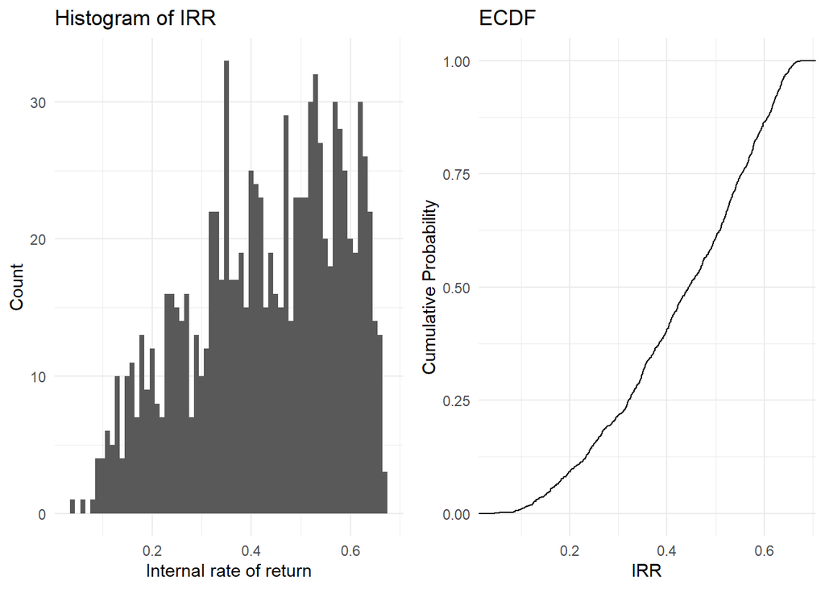